# NLP

[figure not shown]

```python
# To add the Title page
from IPython import display # From the library
display.Image("1.png") # To display
```

[figure not shown]

```python
# To add the Title page
from IPython import display # From the library
display.Image("2.png") # To display
```

## *Summary*

Business Problem

In the rapidly evolving e-commerce landscape, understanding customer sentiment and feedback is crucial for businesses to improve their products and services. Amazon, being a global leader in e-commerce, receives millions of product reviews from customers worldwide. These reviews are a rich source of customer insights but manually analyzing such a vast amount of text data is time-consuming and practically infeasible.

The challenge is to develop an automated system that can process these reviews, identify key topics that customers are talking about, and extract named entities such as product names, organizations, locations, etc. This will help Amazon or any agency to quickly identify common customer complaints, popular products, and other valuable insights that can inform business strategy.

Need to install the packages

```python
# Installing pydavis package
!pip install pyLDAvis
```

```python
!pip install numpy==1.19.3
```

[output not shown]

```python
!pip list
```

[output not shown]

[output cut: 371 more lines]

[output not shown]

## Importing the libraries

```python
import numpy as np
import pandas as pd
import matplotlib.pyplot as plt
import seaborn as sns
from wordcloud import WordCloud
from gensim.utils import simple_preprocess
from nltk.corpus import stopwords
import string
import nltk
nltk.download('stopwords')
import spacy
from gensim.corpora import Dictionary
from gensim.models import CoherenceModel
from matplotlib import pyplot as plt
import gensim
import pyLDAvis
import pyLDAvis.gensim
```

## Uploading te dataset

```python
file_path = 'Amazon Reviews.csv'
data = pd.read_csv(file_path) #Defining the data frame
data.head()
```

|  | id | asins | brand | categories | colors | dateAdded | dateUpdated | dimension | ean | keys | ... | reviews.rating | reviews.sourceURLs | reviews.text | reviews.title | reviews.userCity | reviews.userProvince | reviews.username | sizes | upc | weight |
| --- | --- | --- | --- | --- | --- | --- | --- | --- | --- | --- | --- | --- | --- | --- | --- | --- | --- | --- | --- | --- | --- |
| 0 | AVpe7AsMilAPnD_xQ78G | B00QJDU3KY | Amazon | Amazon Devices,mazon.co.uk | NaN | 2016-03-08T20:21:53Z | 2017-07-18T23:52:58Z | 169 mm x 117 mm x 9.1 mm | NaN | kindlepaperwhite/b00qjdu3ky | ... | 5.0 | https://www.amazon.com/Kindle-Paperwhite-High-... | I initially had trouble deciding between the p... | Paperwhite voyage, no regrets! | NaN | NaN | Cristina M | NaN | NaN | 205 grams |
| 1 | AVpe7AsMilAPnD_xQ78G | B00QJDU3KY | Amazon | Amazon Devices,mazon.co.uk | NaN | 2016-03-08T20:21:53Z | 2017-07-18T23:52:58Z | 169 mm x 117 mm x 9.1 mm | NaN | kindlepaperwhite/b00qjdu3ky | ... | 5.0 | https://www.amazon.com/Kindle-Paperwhite-High-... | Allow me to preface this with a little history... | One Simply Could Not Ask For More | NaN | NaN | Ricky | NaN | NaN | 205 grams |
| 2 | AVpe7AsMilAPnD_xQ78G | B00QJDU3KY | Amazon | Amazon Devices,mazon.co.uk | NaN | 2016-03-08T20:21:53Z | 2017-07-18T23:52:58Z | 169 mm x 117 mm x 9.1 mm | NaN | kindlepaperwhite/b00qjdu3ky | ... | 4.0 | https://www.amazon.com/Kindle-Paperwhite-High-... | I am enjoying it so far. Great for reading. Ha... | Great for those that just want an e-reader | NaN | NaN | Tedd Gardiner | NaN | NaN | 205 grams |
| 3 | AVpe7AsMilAPnD_xQ78G | B00QJDU3KY | Amazon | Amazon Devices,mazon.co.uk | NaN | 2016-03-08T20:21:53Z | 2017-07-18T23:52:58Z | 169 mm x 117 mm x 9.1 mm | NaN | kindlepaperwhite/b00qjdu3ky | ... | 5.0 | https://www.amazon.com/Kindle-Paperwhite-High-... | I bought one of the first Paperwhites and have... | Love / Hate relationship | NaN | NaN | Dougal | NaN | NaN | 205 grams |
| 4 | AVpe7AsMilAPnD_xQ78G | B00QJDU3KY | Amazon | Amazon Devices,mazon.co.uk | NaN | 2016-03-08T20:21:53Z | 2017-07-18T23:52:58Z | 169 mm x 117 mm x 9.1 mm | NaN | kindlepaperwhite/b00qjdu3ky | ... | 5.0 | https://www.amazon.com/Kindle-Paperwhite-High-... | I have to say upfront - I don't like coroporat... | I LOVE IT | NaN | NaN | Miljan David Tanic | NaN | NaN | 205 grams |

5 rows × 27 columns

To check the info of the dataset

## EDA

```python
data.info()
```

```
<class 'pandas.core.frame.DataFrame'>
RangeIndex: 1596 entries, 0 to 1595
Data columns (total 27 columns):
 #   Column                Non-Null Count  Dtype
---  ------                --------------  -----
 0   id                    1596 non-null   object
 1   asins                 1596 non-null   object
 2   brand                 1596 non-null   object
 3   categories            1596 non-null   object
 4   colors                773 non-null    object
 5   dateAdded             1596 non-null   object
 6   dateUpdated           1596 non-null   object
 7   dimension             564 non-null    object
 8   ean                   897 non-null    float64
 9   keys                  1596 non-null   object
```

[output cut: 19 more lines]

```python
# Basic dataset information
print(f'Number of rows: {data.shape[0]}')
print(f'Number of columns: {data.shape[1]}')
print('\nColumn Names:')
print(data.columns.tolist())
print('\nMissing values:')
print(data.isnull().sum())
```

```
Number of rows: 1596
Number of columns: 27

Column Names:
['id', 'asins', 'brand', 'categories', 'colors', 'dateAdded', 'dateUpdated', 'dimension', 'ean', 'keys', 'manufacturer', 'manufacturerNumber', 'name', 'prices', 'reviews.date', 'reviews.doRecommend', 'reviews.numHelpful', 'reviews.rating', 'reviews.sourceURLs', 'reviews.text', 'reviews.title', 'revi…

Missing values:
id                         0
asins                      0
brand                      0
categories                 0
colors                   823
dateAdded                  0
dateUpdated                0
dimension               1032
ean                      699
keys                       0
manufacturer             632
manufacturerNumber       695
name                       0
prices                     0
reviews.date             380
reviews.doRecommend     1058
reviews.numHelpful       697
reviews.rating           420
reviews.sourceURLs         0
reviews.text               0
reviews.title             17
reviews.userCity        1596
reviews.userProvince    1596
reviews.username          17
sizes                   1596
upc                      699
weight                   911
dtype: int64
```

```python
data['reviews.date'].value_counts
```

```
<bound method IndexOpsMixin.value_counts of 0       2015-08-08T00:00:00.000Z
1       2015-09-01T00:00:00.000Z
2       2015-07-20T00:00:00.000Z
3       2017-06-16T00:00:00.000Z
4       2016-08-11T00:00:00.000Z
                  ...
1591    2016-07-06T00:00:00.000Z
1592    2016-06-22T00:00:00.000Z
1593    2016-03-31T00:00:00.000Z
1594        2016-04-26T00:00:00Z
1595        2016-07-31T00:00:00Z
Name: reviews.date, Length: 1596, dtype: object>
```

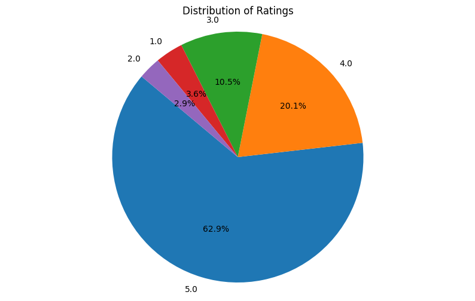

```python
# Distribution of ratings with a pie chart
ratings = data['reviews.rating'].value_counts()
plt.figure(figsize=(10, 6))
plt.pie(ratings, labels=ratings.index, autopct='%1.1f%%', startangle=140)
plt.axis('equal')
plt.title('Distribution of Ratings')
plt.show()
```

As we can see that the distribution of the rating

- 5 - 62.9 %
- 4 - 20 %

To filter the dataset on one product

```python
data[data['asins']=='B01BH83OOM']['name'][854]
```

```
'Amazon Tap - Alexa-Enabled Portable Bluetooth Speaker'
```

## the analysis on this product

```python
# filter for product id = amazon tap
data = data[data['asins']=="B01BH83OOM"]
data.head(3)
```

|  | id | asins | brand | categories | colors | dateAdded | dateUpdated | dimension | ean | keys | ... | reviews.rating | reviews.sourceURLs | reviews.text | reviews.title | reviews.userCity | reviews.userProvince | reviews.username | sizes | upc | weight |
| --- | --- | --- | --- | --- | --- | --- | --- | --- | --- | --- | --- | --- | --- | --- | --- | --- | --- | --- | --- | --- | --- |
| 852 | AVpfpK8KLJeJML43BCuD | B01BH83OOM | Amazon | Amazon Devices,Home,Smart Home & Connected Liv... | Black | 2017-01-04T03:51:17Z | 2017-08-13T08:31:07Z | 4.8 in x 6.6 in x 3.2 in | 8.420000e+11 | amazontapalexaenabledportablebluetoothspeaker/... | ... | 5.0 | https://www.amazon.com/dp/B01BH83OOM,https://w... | IMPORTANT UPDATE (3/8/17): As you read my orig... | The Echo's Little Sister Is AMAZING!! 3, | NaN | NaN | Deanokat | NaN | 8.420000e+11 | 1.75 lbs |
| 853 | AVpfpK8KLJeJML43BCuD | B01BH83OOM | Amazon | Amazon Devices,Home,Smart Home & Connected Liv... | Black | 2017-01-04T03:51:17Z | 2017-08-13T08:31:07Z | 4.8 in x 6.6 in x 3.2 in | 8.420000e+11 | amazontapalexaenabledportablebluetoothspeaker/... | ... | 5.0 | https://www.amazon.com/dp/B01BH83OOM,https://w... | It was just a few weeks ago that I was bemoani... | Tap Alexa on the go! | NaN | NaN | Heather A | NaN | 8.420000e+11 | 1.75 lbs |
| 854 | AVpfpK8KLJeJML43BCuD | B01BH83OOM | Amazon | Amazon Devices,Home,Smart Home & Connected Liv... | Black | 2017-01-04T03:51:17Z | 2017-08-13T08:31:07Z | 4.8 in x 6.6 in x 3.2 in | 8.420000e+11 | amazontapalexaenabledportablebluetoothspeaker/... | ... | 5.0 | https://www.amazon.com/dp/B01BH83OOM,https://w... | The Amazon Tap is a portable Bluetooth speaker... | Amazon Tap Review - Best Bluetooth Speaker in ... | NaN | NaN | Quentin Moore | NaN | 8.420000e+11 | 1.75 lbs |

3 rows × 27 columns

```python
print(data.columns)
print(data['reviews.text'].head())
```

```
Index(['id', 'asins', 'brand', 'categories', 'colors', 'dateAdded',
       'dateUpdated', 'dimension', 'ean', 'keys', 'manufacturer',
       'manufacturerNumber', 'name', 'prices', 'reviews.date',
       'reviews.doRecommend', 'reviews.numHelpful', 'reviews.rating',
       'reviews.sourceURLs', 'reviews.text', 'reviews.title',
       'reviews.userCity', 'reviews.userProvince', 'reviews.username', 'sizes',
       'upc', 'weight'],
      dtype='object')
852    IMPORTANT UPDATE (3/8/17): As you read my orig...
853    It was just a few weeks ago that I was bemoani...
854    The Amazon Tap is a portable Bluetooth speaker...
855    Look at this product as a portable speaker fir...
856    This Amazon tap is not only a great Bluetooth ...
Name: reviews.text, dtype: object
```

```python
print(data['reviews.rating'].unique())
```

```
[5. 4. 2. 3. 1.]
```

```python
print(data['reviews.rating'].value_counts())
```

```
reviews.rating
5.0    357
4.0    139
3.0     28
2.0     10
1.0      7
Name: count, dtype: int64
```

The code to plot the bar graph for the review

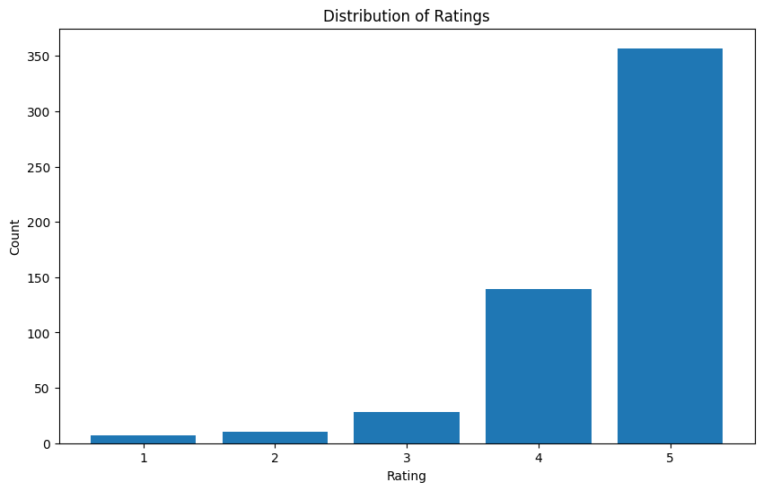

```python
ratings_counts = data['reviews.rating'].value_counts().sort_index()
plt.figure(figsize=(10, 6))
plt.bar(ratings_counts.index, ratings_counts.values)
plt.title('Distribution of Ratings')
plt.xlabel('Rating')
plt.ylabel('Count')
plt.show()
```

Now, I am going to visualize the text data avaialble on the dataset

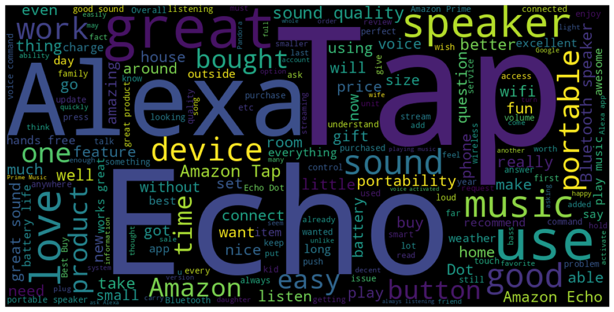

```python
# Word cloud for reviews


wordcloud = WordCloud(width = 1000, height = 500).generate(' '.join(data['reviews.text']))

plt.figure(figsize=(15, 8))
plt.imshow(wordcloud)
plt.axis('off')
plt.show()
```

- The resulting word cloud visually represents the most frequent words in the 'reviews.text' column of your DataFrame. The size of each word in the word cloud corresponds to its frequency in the text data.

## Preprocessing

For this there is a algorithm which I am going to build, which involves

- Tokenize each review (using gensim)
- Remove stop words (including punctuations)
- Lemmatize (using spacy)

Lemmatization is an crutial step and its highly recommended because when building topic models,Without lemmatization, there is a risk of generating topics that contain similar words, such as "Cream" and "Creams," which essentially refer to the same concept.

```python
#Tokenization using Gensim's simple_preprocess

def tokenize(text):
    return simple_preprocess(text, deacc=True)  # deacc=True removes punctuations
data['tokens'] = data['reviews.text'].apply(tokenize)
data['tokens'].head(20)
```

```
852    [important, update, as, you, read, my, origina...
853    [it, was, just, few, weeks, ago, that, was, be...
854    [the, amazon, tap, is, portable, bluetooth, sp...
855    [look, at, this, product, as, portable, speake...
856    [this, amazon, tap, is, not, only, great, blue...
857    [bought, this, on, deal, of, the, day, which, ...
858    [amazing, sound, all, around, great, product, ...
859    [have, owned, the, echo, for, about, year, now...
860    [really, like, my, tap, very, much, it, great,...
861    [have, owned, three, versions, of, the, amazon...
862    [use, this, speaker, daily, and, love, the, so...
863    [got, it, on, pretty, good, sale, so, feel, it...
864    [have, regular, echo, and, now, the, tap, both...
865    [great, sound, easily, portable, around, the, ...
866    [wanted, to, buy, tap, when, it, was, first, r...
867    [was, little, difficult, to, sync, the, first,...
868    [have, few, top, end, bluetooth, speakers, and...
869    [we, now, have, one, for, everyone, in, the, f...
870    [great, product, for, intro, to, an, ai, devic...
871    [the, more, use, this, the, more, reasons, enj...
Name: tokens, dtype: object
```

- So, the output shows the tokenized words, The resulting 'tokens' column contains lists of tokens for each row in the 'reviews.text' column.
- Each token represents a word in the corresponding review text after being processed by the simple_preprocess function. The tokens are generated by splitting the text into individual words, converting them to lowercase, and removing any accents or punctuation.

Now I am going to write a code, to do the same thing in another way along with the graph

```
                                         review_words  num_words
0   [important, update, as, you, read, my, origina...        292
1   [it, was, just, few, weeks, ago, that, was, be...        187
2   [the, amazon, tap, is, portable, bluetooth, sp...        290
3   [look, at, this, product, as, portable, speake...         93
4   [this, amazon, tap, is, not, only, great, blue...        226
5   [bought, this, on, deal, of, the, day, which, ...         64
6   [amazing, sound, all, around, great, product, ...         10
7   [have, owned, the, echo, for, about, year, now...         65
8   [really, like, my, tap, very, much, it, great,...         63
9   [have, owned, three, versions, of, the, amazon...         49
10  [use, this, speaker, daily, and, love, the, so...         38
11  [got, it, on, pretty, good, sale, so, feel, it...         39
12  [have, regular, echo, and, now, the, tap, both...         22
13  [great, sound, easily, portable, around, the, ...         27
```

[output cut: 16 more lines]

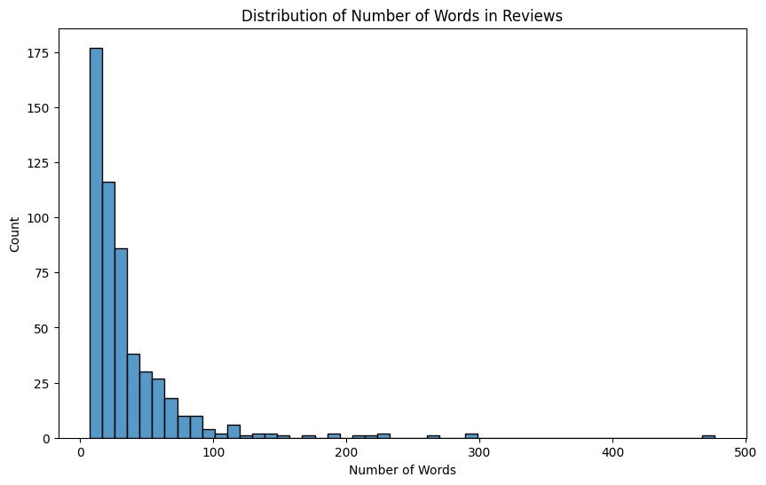

```python
# Function to convert sentences to words
def sent_to_words(sentences, deacc=True):  # deacc=True removes punctuations
    for sentence in sentences:
        yield(simple_preprocess(str(sentence), deacc=deacc))

# Converting to list
data_list = data['reviews.text'].values.tolist()
data_words = list(sent_to_words(data_list))

# Creating a DataFrame from the list of words
data_words_df = pd.DataFrame({'review_words': data_words})

# Adding a column with the number of words in each review
data_words_df['num_words'] = data_words_df['review_words'].apply(len)

# Printing the first 5 rows of the DataFrame
print(data_words_df.head(30))

# Ploting the distribution of the number of words in the reviews
plt.figure(figsize=(10, 6))
sns.histplot(data_words_df['num_words'], bins=50)
plt.title('Distribution of Number of Words in Reviews')
plt.xlabel('Number of Words')
plt.ylabel('Count')
plt.show()
```

The next step is to creating a list of stop words.

In this case, stopwords.words('english') returns a list of stopwords specific to the English language. Stopwords are commonly occurring words that are often removed from text data during natural language processing tasks because they do not carry significant meaning and can be considered noise in the analysis.

```python
stop_words= stopwords.words('english') + list(string.punctuation)
```

Further analysis

I am going to preprocess and filter the data further, These preprocessing steps help remove stopwords and perform lemmatization to transform the text data into a cleaner and more meaningful representation,

```python
import spacy
from gensim.utils import simple_preprocess
from nltk.corpus import stopwords

# Defining a list of stopwords
stopword_list = set(stopwords.words('english'))

# Defining functions for stopwords, bigrams, trigrams and lemmatization
def eliminate_stopwords(texts):
    return [[word for word in simple_preprocess(str(document)) if word not in stopword_list] for document in texts]

def perform_lemmatization(texts, allowed_postags=['NOUN', 'ADJ', 'VERB', 'ADV']):
    output_texts = []
    for text in texts:
        doc = nlp(' '.join(text))
        output_texts.append([token.lemma_ for token in doc if token.pos_ in allowed_postags])
    return output_texts

# Removing Stop Words
data_words_no_stops = eliminate_stopwords(data_words)

# Initialize spacy 'en_core_web_sm' model, keeping only tagger component (for efficiency)
nlp = spacy.load('en_core_web_sm', disable=['parser', 'ner'])

#  lemmatization keeping only noun, adj, vb, adv
data_lemmatized = perform_lemmatization(data_words_no_stops, allowed_postags=['NOUN', 'ADJ', 'VERB', 'ADV'])

# Print the third document after lemmatization
print(data_lemmatized[3])
```

```
['look', 'product', 'portable', 'speaker', 'second', 'big', 'reason', 'buy', 'standard', 'wifi', 'streaming', 'enable', 'home', 'stream', 'music', 'ease', 'voice', 'recognition', 'top', 'notch', 'really', 'shine', 'use', 'smart', 'home', 'accessory', 'problem', 'tap', 'microphone', 'button', 'listen…
```

```python
# Compare the original text and the processed text
# Note that 'speakers' is lemmatized to 'speaker'
print('Original Text:\n', ' '.join(data_words[3]))
print('\nProcessed Text:\n', ' '.join(data_lemmatized[3]))
```

```
Original Text:
 look at this product as portable speaker first and an echo replacement second the big reason to buy this over standard bluetooth speakers is this has wifi streaming enabled when you are at home you can stream music with ease to it voice recognition is top notch and it really shines when using it wi…

Processed Text:
 look product portable speaker second big reason buy standard wifi streaming enable home stream music ease voice recognition top notch really shine use smart home accessory problem tap microphone button listen voice want big sound always listen feature spend extra money
```

The next step is to convert the text data into a numerical representation that can be used as input for the LDA algorithm.

```python
# Create Dictionary
id2word = Dictionary(data_lemmatized)

# Create Corpus
texts = data_lemmatized

# Term Document Frequency
corpus = [id2word.doc2bow(text) for text in texts]

# View
print(corpus[:1])
```

```
[[(0, 1), (1, 1), (2, 1), (3, 1), (4, 1), (5, 1), (6, 1), (7, 2), (8, 1), (9, 1), (10, 1), (11, 1), (12, 1), (13, 3), (14, 1), (15, 2), (16, 1), (17, 1), (18, 1), (19, 1), (20, 1), (21, 2), (22, 1), (23, 1), (24, 3), (25, 1), (26, 1), (27, 2), (28, 2), (29, 1), (30, 1), (31, 1), (32, 1), (33, 1), (3…
```

"Creating a Bag-of-Words Corpus: Generating Word Frequency Distribution"

```python
for doc in corpus[:1]:
    for id, freq in doc:
        print(f'{id2word[id]}: {freq}')
```

```
admit: 1
alexa: 1
allow: 1
amazon: 1
announce: 1
answer: 1
anyway: 1
app: 2
appealing: 1
associate: 1
avid: 1
aware: 1
back: 1
battery: 3
buy: 1
choose: 2
command: 1
control: 1
convenience: 1
cook: 1
day: 1
decide: 2
demand: 1
development: 1
device: 3
dot: 1
drain: 1
early: 2
easily: 2
echo: 1
enable: 1
especially: 1
fabulous: 1
financial: 1
firmware: 1
first: 1
free: 6
get: 1
give: 1
go: 1
```

[output cut: 47 more lines]

```
thing: 1
think: 1
thrill: 1
time: 1
today: 1
toggle: 1
touch: 1
try: 1
update: 2
use: 4
voice: 2
want: 2
well: 1
whole: 1
wonderful: 1
```

The purpose of the above code is to demonstrate the conversion of the document into a bag-of-words representation. By printing the word IDs and frequencies, you can observe how the words in the document are represented numerically.

In the given output, each line represents a word and its corresponding frequency in the first document of the corpus.

- important: 1: The word "important" appears once in the document.
- little: 2: The word "little" appears twice in the document.

Now Going to build the LDA model

```python
# Building LDA model
lda_model_topic = gensim.models.LdaMulticore(corpus=corpus,
                                             id2word=id2word,
                                             num_topics=10,
                                             random_state=100,
                                             chunksize=100,
                                             passes=100,  # Increase the number of passes
                                             per_word_topics=True)
```

```python
# Print the Keyword in the 10 topics
print(lda_model_topic.print_topics())
doc_lda_topic = lda_model_topic[corpus]
```

```
[(0, '0.095*"use" + 0.027*"time" + 0.026*"enjoy" + 0.020*"really" + 0.019*"take" + 0.017*"travel" + 0.016*"sync" + 0.015*"awesome" + 0.014*"pool" + 0.013*"beach"'), (1, '0.064*"sound" + 0.042*"great" + 0.039*"speaker" + 0.036*"good" + 0.030*"alexa" + 0.025*"quality" + 0.025*"love" + 0.025*"tap" + 0.…
```

```python
# Compute Coherence Score
coherence_model_lda_topic = CoherenceModel(model=lda_model_topic, texts=data_lemmatized, dictionary=id2word, coherence='c_v')
coherence_lda_topic = coherence_model_lda_topic.get_coherence()
print('\nCoherence Score: ', coherence_lda_topic)
```

```
Coherence Score:  0.39214778759131874
```

```python
!pip install pyLDAvis
```

```python
import pyLDAvis.gensim_models

# Enable notebook mode
pyLDAvis.enable_notebook()

# Prepare the visualization
vis = pyLDAvis.gensim_models.prepare(lda_model_topic, corpus, id2word, n_jobs=1)

# Display the visualization
vis
```

[interactive chart not shown]

The output is a visual representation of the topic model, which includes several components

- Topic Distribution Bar Chart
- Intertopic Distance Map
- Term Frequency and Relevance
- As we can see from the output that there are a lot of overlapping and no clarity as such. *Each one of the circles represents a different Topic or a different cluster on the graph.
- Hence we going to do modify process and tune the data

## Hyper parameter tuning

Now creating a function "compute_coherence_values_tuning" for tuning the LDA model by evaluating different combinations of the number of topics and alpha values which includes various Parameters, like

- dictionary
- corpus
- texts
- num_topics_range
- alpha_range

```python
def compute_coherence_values_tuning(dictionary, corpus, texts, num_topics_range, alpha_range):
    coherence_values_tuning = []
    model_list_tuning = []
    for num_topics in num_topics_range:
        for alpha in alpha_range:
            model_tuning = gensim.models.LdaMulticore(corpus=corpus, num_topics=num_topics, id2word=dictionary, alpha=alpha)
            model_list_tuning.append(model_tuning)
            coherencemodel_tuning = CoherenceModel(model=model_tuning, texts=texts, dictionary=dictionary, coherence='c_v')
            coherence_values_tuning.append({'num_topics': num_topics, 'alpha': alpha, 'coherence': coherencemodel_tuning.get_coherence()})

    return model_list_tuning, coherence_values_tuning
```

Now I am going to write a code to explores different combinations of num_topics and alpha values and computes the coherence scores for each combination.

```python
num_topics_range = [2, 6, 10, 15, 20]
alpha_range = [0.01, 0.1, 1]

model_list_tuning, coherence_values_tuning = compute_coherence_values_tuning(dictionary=id2word, corpus=corpus, texts=data_lemmatized, num_topics_range=num_topics_range, alpha_range=alpha_range)

# Converting the coherence values to a DataFrame
coherence_df_tuning = pd.DataFrame(coherence_values_tuning)
coherence_df_tuning
```

|  | num_topics | alpha | coherence |
| --- | --- | --- | --- |
| 0 | 2 | 0.01 | 0.505827 |
| 1 | 2 | 0.10 | 0.466401 |
| 2 | 2 | 1.00 | 0.475275 |
| 3 | 6 | 0.01 | 0.417317 |
| 4 | 6 | 0.10 | 0.413429 |
| 5 | 6 | 1.00 | 0.465982 |
| 6 | 10 | 0.01 | 0.434684 |
| 7 | 10 | 0.10 | 0.404719 |
| 8 | 10 | 1.00 | 0.463410 |
| 9 | 15 | 0.01 | 0.396472 |
| 10 | 15 | 0.10 | 0.393648 |
| 11 | 15 | 1.00 | 0.467204 |
| 12 | 20 | 0.01 | 0.389393 |
| 13 | 20 | 0.10 | 0.408423 |
| 14 | 20 | 1.00 | 0.461834 |

Next step is to visualize the coherence values for different combinations of alpha values and the number of topics.

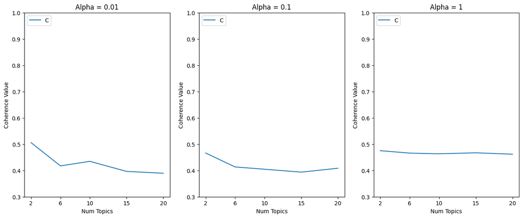

```python
# Defining the function to plot coherence values
def plot_coherence(coherence_df, alpha_range, num_topics_range):
    plt.figure(figsize=(16,6))

    for i, alpha in enumerate(alpha_range):
        plt.subplot(1, len(alpha_range), i+1)
        alpha_subset = coherence_df[coherence_df['alpha'] == alpha]
        plt.plot(alpha_subset['num_topics'], alpha_subset['coherence'])
        plt.xlabel('Num Topics')
        plt.ylabel('Coherence Value')
        plt.title('Alpha = {0}'.format(alpha))
        plt.ylim([0.30, 1])
        plt.legend('Coherence Value', loc='upper left')
        plt.xticks(num_topics_range)

# Plotting  the coherence values
plot_coherence(coherence_df_tuning, alpha_range, num_topics_range)
```

Now going to create a final model, The reason for creating a final model is to train an LDA model with specific hyperparameters that you have determined to be the most suitable for your dataset.

```python
Final_LDA_model = gensim.models.ldamodel.LdaModel(corpus=corpus,
                                                  id2word=id2word,
                                                  num_topics=6,
                                                  random_state=100,
                                                  update_every=1,
                                                  chunksize=100,
                                                  passes=10,
                                                  alpha=1,
                                                  per_word_topics=True)
```

Now continuing with the steps as performed earlier

```python
print(Final_LDA_model.print_topics())
doc_lda = Final_LDA_model[corpus]
```

```
[(0, '0.062*"use" + 0.028*"enjoy" + 0.025*"able" + 0.021*"question" + 0.020*"little" + 0.019*"ask" + 0.018*"hand" + 0.017*"tap" + 0.016*"app" + 0.015*"alexa"'), (1, '0.114*"sound" + 0.064*"great" + 0.056*"good" + 0.041*"quality" + 0.027*"easy" + 0.025*"speaker" + 0.024*"well" + 0.022*"alexa" + 0.018…
```

```python
# coherence score
coherence_model_lda = CoherenceModel(model=Final_LDA_model, texts=data_lemmatized, dictionary=id2word, coherence='c_v')
coherence_lda = coherence_model_lda.get_coherence()
print('\nCoherence Score: ', coherence_lda)
```

```
Coherence Score:  0.40847322763332355
```

```python
# visualizing the topics
pyLDAvis.enable_notebook()
vis = pyLDAvis.gensim.prepare(Final_LDA_model, corpus, id2word)
vis
```

[interactive chart not shown]

So from the output,

- There is much better clustering of topics
- The overlapping has been reduced After adjusting the topics , it seems that the clarity is much better regarding the product I chose to do the analysis.

Now another Method to do is called NER, Name entity Recognition

- Named Entity Recognition (NER) is a process where an algorithm takes a string of text (sentence or paragraph) as input and identifies relevant nouns (people, places, and organizations) that are mentioned in that string.
- ORG (Organizations)
- PERSON (Persons)
- GPE (Geo-Political Entity)
- DATES/TIME
- MONEY

```python
import spacy
from spacy import displacy
from collections import Counter
import en_core_web_sm
nlp = en_core_web_sm.load()

# Function to extract Named Entities
def extract_named_entities(text):
    doc = nlp(text)
    return [(X.text, X.label_) for X in doc.ents]

# Appling the function to the 'headline_text' column
data['named_entities'] = data['reviews.text'].apply(extract_named_entities)
data.head()
```

|  | id | asins | brand | categories | colors | dateAdded | dateUpdated | dimension | ean | keys | ... | reviews.text | reviews.title | reviews.userCity | reviews.userProvince | reviews.username | sizes | upc | weight | tokens | named_entities |
| --- | --- | --- | --- | --- | --- | --- | --- | --- | --- | --- | --- | --- | --- | --- | --- | --- | --- | --- | --- | --- | --- |
| 852 | AVpfpK8KLJeJML43BCuD | B01BH83OOM | Amazon | Amazon Devices,Home,Smart Home & Connected Liv... | Black | 2017-01-04T03:51:17Z | 2017-08-13T08:31:07Z | 4.8 in x 6.6 in x 3.2 in | 8.420000e+11 | amazontapalexaenabledportablebluetoothspeaker/... | ... | IMPORTANT UPDATE (3/8/17): As you read my orig... | The Echo's Little Sister Is AMAZING!! 3, | NaN | NaN | Deanokat | NaN | 8.420000e+11 | 1.75 lbs | [important, update, as, you, read, my, origina... | [(3/8/17, CARDINAL), (Amazon, ORG), (early Feb... |
| 853 | AVpfpK8KLJeJML43BCuD | B01BH83OOM | Amazon | Amazon Devices,Home,Smart Home & Connected Liv... | Black | 2017-01-04T03:51:17Z | 2017-08-13T08:31:07Z | 4.8 in x 6.6 in x 3.2 in | 8.420000e+11 | amazontapalexaenabledportablebluetoothspeaker/... | ... | It was just a few weeks ago that I was bemoani... | Tap Alexa on the go! | NaN | NaN | Heather A | NaN | 8.420000e+11 | 1.75 lbs | [it, was, just, few, weeks, ago, that, was, be... | [(just a few weeks ago, DATE), (Echo, LOC), (l... |
| 854 | AVpfpK8KLJeJML43BCuD | B01BH83OOM | Amazon | Amazon Devices,Home,Smart Home & Connected Liv... | Black | 2017-01-04T03:51:17Z | 2017-08-13T08:31:07Z | 4.8 in x 6.6 in x 3.2 in | 8.420000e+11 | amazontapalexaenabledportablebluetoothspeaker/... | ... | The Amazon Tap is a portable Bluetooth speaker... | Amazon Tap Review - Best Bluetooth Speaker in ... | NaN | NaN | Quentin Moore | NaN | 8.420000e+11 | 1.75 lbs | [the, amazon, tap, is, portable, bluetooth, sp... | [(The Amazon Tap, ORG), (Dolby, PRODUCT), (The... |
| 855 | AVpfpK8KLJeJML43BCuD | B01BH83OOM | Amazon | Amazon Devices,Home,Smart Home & Connected Liv... | Black | 2017-01-04T03:51:17Z | 2017-08-13T08:31:07Z | 4.8 in x 6.6 in x 3.2 in | 8.420000e+11 | amazontapalexaenabledportablebluetoothspeaker/... | ... | Look at this product as a portable speaker fir... | Great for what it does | NaN | NaN | Casey | NaN | 8.420000e+11 | 1.75 lbs | [look, at, this, product, as, portable, speake... | [(first, ORDINAL), (Echo, LOC), (second, ORDIN... |
| 856 | AVpfpK8KLJeJML43BCuD | B01BH83OOM | Amazon | Amazon Devices,Home,Smart Home & Connected Liv... | Black | 2017-01-04T03:51:17Z | 2017-08-13T08:31:07Z | 4.8 in x 6.6 in x 3.2 in | 8.420000e+11 | amazontapalexaenabledportablebluetoothspeaker/... | ... | This Amazon tap is not only a great Bluetooth ... | Awesome, smart little portable speaker | NaN | NaN | Tazman3582 | NaN | 8.420000e+11 | 1.75 lbs | [this, amazon, tap, is, not, only, great, blue... | [(Amazon, ORG), (half, CARDINAL), (5 minutes, ... |

5 rows × 29 columns

As we can see an extra col has been created as " named_entities"

```python
data.head()
```

|  | id | asins | brand | categories | colors | dateAdded | dateUpdated | dimension | ean | keys | ... | reviews.text | reviews.title | reviews.userCity | reviews.userProvince | reviews.username | sizes | upc | weight | tokens | named_entities |
| --- | --- | --- | --- | --- | --- | --- | --- | --- | --- | --- | --- | --- | --- | --- | --- | --- | --- | --- | --- | --- | --- |
| 852 | AVpfpK8KLJeJML43BCuD | B01BH83OOM | Amazon | Amazon Devices,Home,Smart Home & Connected Liv... | Black | 2017-01-04T03:51:17Z | 2017-08-13T08:31:07Z | 4.8 in x 6.6 in x 3.2 in | 8.420000e+11 | amazontapalexaenabledportablebluetoothspeaker/... | ... | IMPORTANT UPDATE (3/8/17): As you read my orig... | The Echo's Little Sister Is AMAZING!! 3, | NaN | NaN | Deanokat | NaN | 8.420000e+11 | 1.75 lbs | [important, update, as, you, read, my, origina... | [(3/8/17, CARDINAL), (Amazon, ORG), (early Feb... |
| 853 | AVpfpK8KLJeJML43BCuD | B01BH83OOM | Amazon | Amazon Devices,Home,Smart Home & Connected Liv... | Black | 2017-01-04T03:51:17Z | 2017-08-13T08:31:07Z | 4.8 in x 6.6 in x 3.2 in | 8.420000e+11 | amazontapalexaenabledportablebluetoothspeaker/... | ... | It was just a few weeks ago that I was bemoani... | Tap Alexa on the go! | NaN | NaN | Heather A | NaN | 8.420000e+11 | 1.75 lbs | [it, was, just, few, weeks, ago, that, was, be... | [(just a few weeks ago, DATE), (Echo, LOC), (l... |
| 854 | AVpfpK8KLJeJML43BCuD | B01BH83OOM | Amazon | Amazon Devices,Home,Smart Home & Connected Liv... | Black | 2017-01-04T03:51:17Z | 2017-08-13T08:31:07Z | 4.8 in x 6.6 in x 3.2 in | 8.420000e+11 | amazontapalexaenabledportablebluetoothspeaker/... | ... | The Amazon Tap is a portable Bluetooth speaker... | Amazon Tap Review - Best Bluetooth Speaker in ... | NaN | NaN | Quentin Moore | NaN | 8.420000e+11 | 1.75 lbs | [the, amazon, tap, is, portable, bluetooth, sp... | [(The Amazon Tap, ORG), (Dolby, PRODUCT), (The... |
| 855 | AVpfpK8KLJeJML43BCuD | B01BH83OOM | Amazon | Amazon Devices,Home,Smart Home & Connected Liv... | Black | 2017-01-04T03:51:17Z | 2017-08-13T08:31:07Z | 4.8 in x 6.6 in x 3.2 in | 8.420000e+11 | amazontapalexaenabledportablebluetoothspeaker/... | ... | Look at this product as a portable speaker fir... | Great for what it does | NaN | NaN | Casey | NaN | 8.420000e+11 | 1.75 lbs | [look, at, this, product, as, portable, speake... | [(first, ORDINAL), (Echo, LOC), (second, ORDIN... |
| 856 | AVpfpK8KLJeJML43BCuD | B01BH83OOM | Amazon | Amazon Devices,Home,Smart Home & Connected Liv... | Black | 2017-01-04T03:51:17Z | 2017-08-13T08:31:07Z | 4.8 in x 6.6 in x 3.2 in | 8.420000e+11 | amazontapalexaenabledportablebluetoothspeaker/... | ... | This Amazon tap is not only a great Bluetooth ... | Awesome, smart little portable speaker | NaN | NaN | Tazman3582 | NaN | 8.420000e+11 | 1.75 lbs | [this, amazon, tap, is, not, only, great, blue... | [(Amazon, ORG), (half, CARDINAL), (5 minutes, ... |

5 rows × 29 columns

```python
print(data['named_entities'])
```

```
852     [(3/8/17, CARDINAL), (Amazon, ORG), (early Feb...
853     [(just a few weeks ago, DATE), (Echo, LOC), (l...
854     [(The Amazon Tap, ORG), (Dolby, PRODUCT), (The...
855     [(first, ORDINAL), (Echo, LOC), (second, ORDIN...
856     [(Amazon, ORG), (half, CARDINAL), (5 minutes, ...
                              ...
1388                                      [(Amazon, ORG)]
1389                           [(7 and 5 year old, DATE)]
1390                                                   []
1391                                                   []
1392            [(Echo, ORG), (Alexa, ORG), (Alexa, ORG)]
Name: named_entities, Length: 541, dtype: object
```

So from the output for example lets take the first row, (3/8/17, CARDINAL): It identifies the date "3/8/17" as a cardinal number (CARDINAL).

(Amazon, ORG): It recognizes "Amazon" as an organization (ORG).

(early Feb..., DATE): It identifies the phrase "early Feb..." as a date (DATE).

## Conclusion

Lastly, I want to thank you Dr. for teaching us, Your teachings have truly enriched our understanding and paved the way for our academic growth and professional growth